# Obtain phylogenetic and interaction distances

```r
#source("../Original_code/functions/tree_functions.R")
#source("../Original_code/functions/phylo_functions.R")
source("AF_code/AF_functions_tree.R")
```

### Load simulation data

FOODWEB

```r
n_steps
```

```
[1] 167
```

COMPETITION

```r
n_steps
```

```
[1] 176
```

FACILITATION

```r
load("./Data/Positive_interactions/list_res_pos_2.Rdata")
```

The presence_matrix (rows = timesteps, cols = species, entries = 1,0) has extra timesteps in case the simulation is longer (max = 350), so I crop it to the number of timesteps in the simulation:

```r
presence_matrix <- list_simulation1$presence_matrix

presence_matrix <- presence_matrix[1:n_steps,]
```

#### Discard timesteps where phylogenetic distances cant be calculated

It requires at leas 3 species to compute the phylogenetic distances. Check the timestep from which we can make the calculations by looking at the presence_matrix and see which matrices (or timesteps) have less than 3 spp.

```r
non.valid_timesteps_phylo_distance <- c(which(rowSums(presence_matrix) < 3))

print(paste("timesteps 1 to", length(non.valid_timesteps_phylo_distance), "will be discarted as they have less than 3 spp"))
```

```
[1] "timesteps 1 to 4 will be discarted as they have less than 3 spp"
```

#### homogenize elements to start from valid timesteps

Discard those timesteps with less than 3 spp in both the list_anc_dist table (ancestry table) and the network_list:

```r
# ancestry-distances table

list_anc_dist <- list_simulation1$list_anc_dist[-non.valid_timesteps_phylo_distance]



# Network list

network_list <- list_simulation1$network_list[-non.valid_timesteps_phylo_distance]







## ------------------- Check

if (length(which(is.null(list_simulation1$network_list))) > 0) {

  print("check - null network somewhere")
} else {
  print("all good - no null networks")
}
```

```
[1] "all good - no null networks"
```

```r
if(length(list_anc_dist) == length(network_list)){

  print("all good - distance-ancestry table and network list have the same length")
} else {

  print("PROBLEM")
}
```

```
[1] "all good - distance-ancestry table and network list have the same length"
```

## Convert spp names from numbers to letters

Species names in both the ancestry table and the networks are numbers. Convert it into letters with the function **change_sppnames_letters_ancdist.table()** for the ancestry table, and **set_sppNames_numbers()** (because matrices lack colnames and rownames) and **convert_sppnames_toletters()** for the network list:

```r
## ancestry-distances table

list_anc_dist_letters <- lapply(list_anc_dist, change_sppnames_letters_ancdist.table)


## Network list

list_networks_sppnames_numbers <- lapply(network_list, set_sppNames_numbers)

#### convert numbers to letters

list_networks_sppnames_letters <- lapply(list_networks_sppnames_numbers, convert_sppnames_toletters)






## ------------------- Check


if(length(list_anc_dist_letters) == length(list_networks_sppnames_letters)){

  print("all good - distance-ancestry table with letters and network list with leters have the same length")
} else {

  print("PROBLEM")
}
```

```
[1] "all good - distance-ancestry table with letters and network list with leters have the same length"
```

## Loop for obtaining phylogenetic distances:

Without distinguishing predators and preys:

```r
list_newick <- list()
list_trees <- list()
list_newick_tails <- list()
list_dist.phylo <- list()




for (i in 1:length(list_anc_dist_letters)) {


  print(sprintf("step %s", i))

  list_newick[[i]] <- ToPhylo(list_anc_dist_letters[[i]])

  list_newick_tails[[i]] <- paste(list_newick[[i]], "root")

  list_trees[[i]] <- read.tree(text = sub("A root",";",list_newick_tails[[i]]))

  list_dist.phylo[[i]] <- cophenetic.phylo(list_trees[[i]])


}







## ------------------- Check

if (length(which(unlist(lapply(list_dist.phylo, is.null)) == TRUE)) == 0) {

  print("all good - no nulls")
} else {

  print("PROBLEM")

}



if (length(list_dist.phylo) == length(list_networks_sppnames_letters)){

  print("all good - list phylo dist with letters and list interactions with letters have the same length")

}else{

  print("PROBLEM")

}
```

[output not shown]

## Retain only present species in network matrices

For phylogenetic distance matrices, the spp for which distances are calculated are already only the ones present.

But the interaction matrices are 1000 x 1000 (all spp possible), so I need to crop them to retain only present species at each timestep, and test that these correspond to the ones present in the phylogenetic distance matrices at the corresponding timestep.

I use the presence_matrix to retain the species present at each timestep in each network from the network list. So first I need to convert the spp names of the presence_matrix to letters so that they can match with those of the network. Second, I will discard the timesteps already discarted in the phylogenetic distance matrices list and in the network list so that the presence_matrix match in the length of timesteps with them.

```r
# Set the same spp names for the presence_matrix than for the interacion matrices


colnames(presence_matrix) <- seq(1:1000)

colnames(presence_matrix) <- chartr("0123456789", "ABCDEFGHIJ", colnames(presence_matrix))



## ------------------- Check

if(length(which(colnames(presence_matrix) != colnames(list_networks_sppnames_letters[[1]]))) == 0){

  print("all good - spp names in presence_matrix correspond to spp names in network list")

} else {

  print("PROBLEM")
}
```

```
[1] "all good - spp names in presence_matrix correspond to spp names in network list"
```

```r
# Discard same timesteps (rows) than the discarted phylogenetic distance matrices

presence_matrix <- presence_matrix[-non.valid_timesteps_phylo_distance,]




## ------------------- Check

if(nrow(presence_matrix) == length(list_networks_sppnames_letters) &
   nrow(presence_matrix) == length(list_dist.phylo)){

  print("all good - presence matrix, list phylo dist and list interaction networks have the same n_steps")

} else {

  print("PROBLEM")
}
```

```
[1] "all good - presence matrix, list phylo dist and list interaction networks have the same n_steps"
```

Now that the presence_matrix has the spp names with letters and retains the same timesteps than the network list, I will use it to retain only the species present at each timestep in each 1000 x 1000 network:

```r
## crop the interaction matrix with present spp

list_net_present_spp.letters <- list()

for (i in 1:length(list_networks_sppnames_letters)) {

 list_net_present_spp.letters[[i]] <- list_networks_sppnames_letters[[i]][names(which(presence_matrix[i,] == 1)), names(which(presence_matrix[i,] == 1))]

}
```

## Compute interaction distances (NMI)

I will use the function **compute_nmi_aricode_pred()** for predators and **compute_nmi_aricode_prey()** for preys (their differ in whether the NMI is computed for columns or rows, respectively). These compute the NMI using the aricode package.

```r
## DISTANCES AS PREDATORS (columns)


list_interact_distances_pred <- lapply(list_net_present_spp.letters, FUN = compute_nmi_aricode_pred)


## DISTANCES AS PREYS (rows)

list_interact_distances_prey <- lapply(list_net_present_spp.letters, FUN = compute_nmi_aricode_prey)
```

```r
list_interact_distances_pred <- lapply(list_interact_distances_pred, FUN = diag_to0)

list_interact_distances_prey <- lapply(list_interact_distances_prey, FUN = diag_to0)
```

Check that both the list of distance matrices for interactions and for phylogeny have the same length:

```r
if(length(list_dist.phylo) == length(list_interact_distances_pred) &
   length(list_dist.phylo) == length(list_interact_distances_prey)) {

  print("all good - list phylo dist and lists interact dist have the same length")

} else {

  print("PROBLEM")

}
```

```
[1] "all good - list phylo dist and lists interact dist have the same length"
```

Phylogenetic distance matrices retain the extinct species together with the present ones. The following code is just a demonstration:

```r
df.test.phylo <- as.data.frame(list_dist.phylo[[15]])
df.test.int <- as.data.frame(list_interact_distances_pred[[15]])

data_new.phylo <- df.test.phylo[order(names(df.test.phylo)) , order(names(df.test.phylo))]
data_new.int <- df.test.int[order(names(df.test.int)) , order(names(df.test.int))]

length(colnames(data_new.int)) == length(colnames(data_new.phylo))
```

```
[1] FALSE
```

Therefore, I need to retain only present species in the phylogenetic distance matrices.

## For phylogenetic distance matrices, retain only those species present

To do this,

- 1st - order the names of columns and rows of both phylogenetic and interaction distance matrices so that they coincide
- 2nd - Retain in the phylo-distance matrix only those species names that the interaction distance matrix has. This way, I will be retaining only the present species (remember the interaction distance matrices have already retained the present species only when we used the presence_matrix for it)

```r
list_dist.phylo_pres <- list()

for (i in 1:length(list_dist.phylo)) {

  spp_present <- colnames(list_interact_distances_pred[[i]])
  list_dist.phylo_pres[[i]] <- list_dist.phylo[[i]][spp_present ,spp_present]


}
```

```r
## Check that now phylo and interaction distance matrices have the same number of spp, same names, and in the same order


if (length(which(check_colnames_lists(list_dist.phylo_pres, list_interact_distances_pred) == FALSE)) == 0) {

  print("all good - names in phylo dist matrices and interaction matrices pred match")

} else {

  print("PROBLEM")

}
```

```
[1] "all good - names in phylo dist matrices and interaction matrices pred match"
```

```r
if (length(which(check_colnames_lists(list_dist.phylo_pres, list_interact_distances_prey) == FALSE)) == 0) {

  print("all good - names in phylo dist matrices and interaction matrices prey match")

} else {

  print("PROBLEM")

}
```

```
[1] "all good - names in phylo dist matrices and interaction matrices prey match"
```

NOW I’M READY TO COMPUTE CORRELATION

# Compute MDS

First, I need to solve the following problem:

Some species have all 0 in their interactions (either as prey (if all 0 in the row, top predators) or predators (if all 0 in the column, basal spp)). When two spp having all 0 compare with each other, they give NaN instead of 0 (the (1-NMI) should be 0 as they have the same vector of interactions).

Therefore, I assign a 0 to all NaN found.

```r
list_interact_distances_pred_corrected <- list()

for (i in 1:length(list_interact_distances_pred)) {

  list_interact_distances_pred_corrected[[i]] <- convet_nan_to_0_matrix(matrix = list_interact_distances_pred[[i]],
                       marg = 2) # 1 (rows), 2 (col), or c(1,2)

}


list_interact_distances_prey_corrected <- list()

for (i in 1:length(list_interact_distances_prey)) {

  list_interact_distances_prey_corrected[[i]] <- convet_nan_to_0_matrix(matrix = list_interact_distances_prey[[i]],
                       marg = 1) # 1 (rows), 2 (col), or c(1,2)

}



if(length(list_interact_distances_prey_corrected) == length(list_interact_distances_pred_corrected) &
   length(list_interact_distances_prey_corrected) == length(list_dist.phylo_pres)){

  print("all good - lists of phylo dist and interactions have the same length")

} else {

  print("PROBLEM")

}
```

```
[1] "all good - lists of phylo dist and interactions have the same length"
```

To compute the overall distances between species I calculate the mean between the distances as preys and as predators. I do this by looping through the lists (predator distance matrices list, prey distance matrices list), so selecting one matric from each at a given timestep, and computing the mean between them with the function **compute_mean_two_mat_from_list()**:

```r
list_interact_distances_mean_corrected <- list()


for (i in 1:length(list_interact_distances_pred_corrected)) {

 pair_mat <- list(list_interact_distances_pred_corrected[[i]], list_interact_distances_prey_corrected[[i]])

 list_interact_distances_mean_corrected[[i]] <- compute_mean_two_mat_from_list(list = pair_mat)

}


if(length(list_interact_distances_mean_corrected) == length(list_dist.phylo_pres)){

  print("all good - lists of phylo dist and mean interactions have the same length")

} else {

  print("PROBLEM")

}
```

```
[1] "all good - lists of phylo dist and mean interactions have the same length"
```

Now I can compute the MDS:

```r
for (i in 2:(length(list_dist.phylo_pres))-1) {

list_mds.phy[[i]] <- monoMDS(list_dist.phylo_pres[[i]], y = cmdscale(list_dist.phylo_pres[[i]]))

list_mds.int_pred[[i]] <- monoMDS(list_interact_distances_pred_corrected[[i]], y = cmdscale(list_interact_distances_pred_corrected[[i]]))

list_mds.int_prey[[i]] <- monoMDS(list_interact_distances_prey_corrected[[i]], y = cmdscale(list_interact_distances_prey_corrected[[i]]))

list_mds.int_mean[[i]] <- monoMDS(list_interact_distances_mean_corrected[[i]], y = cmdscale(list_interact_distances_mean_corrected[[i]]))



}
```

[output not shown]

# Compute correlation - Procrustes test

I compute a procrustes correlation between interaction distances as predators, preys, or the mean, and the phylogenetic distances. To do this, I use the **protest** and **procrustes** functions from the vegan package.

```r
protest_pred <- list()
procrustes_pred <- list()

protest_prey <- list()
procrustes_prey <- list()

protest_mean <- list()
procrustes_mean <- list()


for (i in 1:length(list_dist.phylo_pres)) {

  protest_pred[[i]] <- protest(list_mds.int_pred[[i]], list_mds.phy[[i]])

  procrustes_pred[[i]] <- procrustes(list_mds.int_pred[[i]],list_mds.phy[[i]])


}

for (i in 1:length(list_dist.phylo_pres)) {

  protest_prey[[i]] <- protest(list_mds.int_prey[[i]], list_mds.phy[[i]])

  procrustes_prey[[i]] <- procrustes(list_mds.int_prey[[i]],list_mds.phy[[i]])


}

for (i in 1:length(list_dist.phylo_pres)) {

  protest_mean[[i]] <- protest(list_mds.int_mean[[i]], list_mds.phy[[i]])

  procrustes_mean[[i]] <- procrustes(list_mds.int_mean[[i]],list_mds.phy[[i]])


}
```

## Create dataframe results

I store the correlation and Pvalue from the tests.

```r
protest_pval_pred <- c()
protest_corr_pred <- c()
protest_t_pred <- c()

protest_pval_prey <- c()
protest_corr_prey <- c()
protest_t_prey <- c()

protest_pval_mean <- c()
protest_corr_mean <- c()
protest_t_mean <- c()

for (i in 1:length(protest_mean)) {

  protest_pval_pred[i] <- protest_pred[[i]]$signif

  protest_corr_pred[i] <-protest_pred[[i]]$t0

  protest_t_pred[i] <-mean(protest_pred[[i]]$t)


  protest_pval_prey[i] <- protest_prey[[i]]$signif

  protest_corr_prey[i] <-protest_prey[[i]]$t0

  protest_t_prey[i] <-mean(protest_prey[[i]]$t)


  protest_pval_mean[i] <- protest_mean[[i]]$signif

  protest_corr_mean[i] <-protest_mean[[i]]$t0

  protest_t_mean[i] <-mean(protest_mean[[i]]$t)


}

discarted_timesteps <- length(list_simulation1$network_list) - length(protest_mean)

timesteps = (discarted_timesteps+1):length(list_simulation1$network_list)


df_signal_time <- data.frame(timesteps,
                            protest_pval_pred,protest_corr_pred,protest_t_pred,
                            protest_pval_prey,protest_corr_prey,protest_t_prey,
                             protest_pval_mean,protest_corr_mean,protest_t_mean)

df_signal_time$sign_pred <- with(df_signal_time, ifelse(protest_pval_pred < 0.051, 'sign', 'non.sign'))
df_signal_time$sign_prey <- with(df_signal_time, ifelse(protest_pval_prey < 0.051, 'sign', 'non.sign'))
df_signal_time$sign_mean <- with(df_signal_time, ifelse(protest_pval_mean < 0.051, 'sign', 'non.sign'))


df_signal_time
```

| timesteps | protest_pval_pred | protest_corr_pred | protest_t_pred | protest_pval_prey | protest_corr_prey | protest_t_prey | protest_pval_mean | protest_corr_mean | protest_t_mean | sign_pred | sign_prey | sign_mean |
| --- | --- | --- | --- | --- | --- | --- | --- | --- | --- | --- | --- | --- |
| 6 | 0.1666667 | 0.95912624 | 0.7097373 | 1.0000000 | 0.62400938 | 0.7243076 | 0.3333333 | 0.71417181 | 0.6646117 | non.sign | non.sign | non.sign |
| 7 | 0.1666667 | 0.96986159 | 0.7175872 | 1.0000000 | 0.62020214 | 0.7327898 | 0.3333333 | 0.70981446 | 0.6708418 | non.sign | non.sign | non.sign |
| 8 | 0.6666667 | 0.66866787 | 0.7397293 | 0.5833333 | 0.67965770 | 0.7353152 | 0.6666667 | 0.71303017 | 0.7415393 | non.sign | non.sign | non.sign |
| 9 | 0.8333333 | 0.46795847 | 0.6075096 | 0.5000000 | 0.59032676 | 0.6007132 | 0.9000000 | 0.37866617 | 0.6019437 | non.sign | non.sign | non.sign |
| 10 | 0.9222222 | 0.10877633 | 0.5027703 | 0.9277778 | 0.10881348 | 0.5027775 | 0.7000000 | 0.37926890 | 0.5024075 | non.sign | non.sign | non.sign |
| 11 | 0.9250000 | 0.21331213 | 0.4193982 | 0.9390000 | 0.19426354 | 0.4270507 | 0.8610000 | 0.25473199 | 0.4325496 | non.sign | non.sign | non.sign |
| 12 | 0.9830000 | 0.13757011 | 0.4646663 | 0.8490000 | 0.28902550 | 0.4674290 | 0.8250000 | 0.31466626 | 0.4672237 | non.sign | non.sign | non.sign |
| 13 | 0.9770000 | 0.13719978 | 0.4683744 | 0.8300000 | 0.29273447 | 0.4697060 | 0.7810000 | 0.32153475 | 0.4614210 | non.sign | non.sign | non.sign |
| 14 | 0.6960000 | 0.32272617 | 0.3380161 | 0.3050000 | 0.45080668 | 0.3784744 | 0.4450000 | 0.38029159 | 0.3700904 | non.sign | non.sign | non.sign |
| 15 | 0.8000000 | 0.27361338 | 0.3135262 | 0.1760000 | 0.47050261 | 0.3557353 | 0.3860000 | 0.39346691 | 0.3594017 | non.sign | non.sign | non.sign |

[output cut: 162 more lines]

```r
NA
NA
```

```r
save(df_signal_time, file = "foodweb_test/df_signal_time.RData")
```

```r
save(df_signal_time, file = "./competition_test/df_signal_time.RData")
```

### Plot phylogenetic signal through time

```r
my.theme<-theme(axis.text=element_text(size=12),
                axis.title = element_text(size = 14),
                legend.position = "top",
                legend.text=element_text(size=10),
                legend.title = element_text(size=12),
                plot.title = element_text(face="bold",size=14,margin=margin(0,0,20,0),hjust = 0.5),
                axis.title.y = element_text(margin = margin(t = 0, r = 15, b = 0, l = 0)),
                axis.title.x = element_text(margin = margin(t = 15, r = 0, b = 0, l = 0)))


p_pred <- ggplot(df_signal_time, aes(x=timesteps, y=protest_t_mean)) +
       geom_line(color="black", linetype="twodash")+
  #geom_point(aes(fill = sign_mean, color=sign_mean), size=2, alpha = 0.7) +
  theme_bw()+
    my.theme+
    scale_colour_manual(values = c("black", "red"))+
    ggtitle("as predators")+
xlab("timesteps")+
  ylab("Phylogenetic signal")


p_prey <- ggplot(df_signal_time, aes(x=timesteps, y=protest_t_mean)) +
       geom_line(color="black", linetype="twodash")+
  #geom_point(aes(fill = sign_mean, color=sign_mean), size=2, alpha = 0.7) +
  theme_bw()+
    my.theme+
    scale_colour_manual(values = c("black", "red"))+
    ggtitle("as preys")+
xlab("timesteps")+
  ylab("Phylogenetic signal")

p_mean <- ggplot(df_signal_time, aes(x=timesteps, y=protest_t_mean)) +
       geom_line(color="black", linetype="twodash")+
  #geom_point(aes(fill = sign_mean, color=sign_mean), size=2, alpha = 0.7) +
  theme_bw()+
    my.theme+
    scale_colour_manual(values = c("black", "red"))+
    ggtitle("facilitation")+
xlab("timesteps")+
  ylab("Phylogenetic signal")
```

### Plot species richness through time

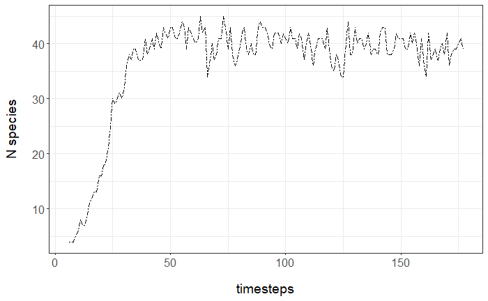

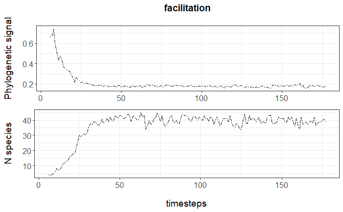

```r
library(ggpubr)

ggarrange(p_mean + rremove("xlab"), p.spp,
             ncol = 1, nrow = 2
             )

ggsave("facilitation_result_phylo.time_1sim.png",
       height = 7,
       width = 7)
```